# Rodrigo Burberg MovieLens Project Question Notebook

### 5. Drop the movie where the genre is unknown - 2.5 marks

```python
#finding the row location of "unkown" movie

Movies.loc[Movies['unknown'] == 1]
```

|  | movie id | movie title | release date | unknown | Action | Adventure | Animation | Childrens | Comedy | Crime | ... | Fantasy | Film-Noir | Horror | Musical | Mystery | Romance | Sci-Fi | Thriller | War | Western |
| --- | --- | --- | --- | --- | --- | --- | --- | --- | --- | --- | --- | --- | --- | --- | --- | --- | --- | --- | --- | --- | --- |
| 1371 | 1373 | Good Morning | 4-Feb-1971 | 1 | 0 | 0 | 0 | 0 | 0 | 0 | ... | 0 | 0 | 0 | 0 | 0 | 0 | 0 | 0 | 0 | 0 |

1 rows × 22 columns

```python
Movies = Movies.drop([1371])

#dropping the entire row where the "unkown" movie was found
```

```python
Movies.shape
```

```
(1680, 22)
```

**Insights:**

Found the location with the loc function and then dropped the entire row.

### 6. Find the movies that have more than one genre - 5 marks

hint: use sum on the axis = 1

Display movie name, number of genres for the movie in dataframe

and also print(total number of movies which have more than one genres)

```python
#your code here

MoviesMoreThanOne = Movies.iloc[:, 3:].sum(axis=1)
MoviesMoreThanOne
```

```
0       3
1       3
2       1
3       3
4       3
       ..
1676    1
1677    2
1678    2
1679    1
1680    1
Length: 1680, dtype: int64
```

```python
Movies["total genre"] = MoviesMoreThanOne

Movies
```

|  | movie id | movie title | release date | unknown | Action | Adventure | Animation | Childrens | Comedy | Crime | ... | Film-Noir | Horror | Musical | Mystery | Romance | Sci-Fi | Thriller | War | Western | total genre |
| --- | --- | --- | --- | --- | --- | --- | --- | --- | --- | --- | --- | --- | --- | --- | --- | --- | --- | --- | --- | --- | --- |
| 0 | 1 | Toy Story | 01-Jan-1995 | 0 | 0 | 0 | 1 | 1 | 1 | 0 | ... | 0 | 0 | 0 | 0 | 0 | 0 | 0 | 0 | 0 | 3 |
| 1 | 2 | GoldenEye | 01-Jan-1995 | 0 | 1 | 1 | 0 | 0 | 0 | 0 | ... | 0 | 0 | 0 | 0 | 0 | 0 | 1 | 0 | 0 | 3 |
| 2 | 3 | Four Rooms | 01-Jan-1995 | 0 | 0 | 0 | 0 | 0 | 0 | 0 | ... | 0 | 0 | 0 | 0 | 0 | 0 | 1 | 0 | 0 | 1 |
| 3 | 4 | Get Shorty | 01-Jan-1995 | 0 | 1 | 0 | 0 | 0 | 1 | 0 | ... | 0 | 0 | 0 | 0 | 0 | 0 | 0 | 0 | 0 | 3 |
| 4 | 5 | Copycat | 01-Jan-1995 | 0 | 0 | 0 | 0 | 0 | 0 | 1 | ... | 0 | 0 | 0 | 0 | 0 | 0 | 1 | 0 | 0 | 3 |
| ... | ... | ... | ... | ... | ... | ... | ... | ... | ... | ... | ... | ... | ... | ... | ... | ... | ... | ... | ... | ... | ... |
| 1676 | 1678 | Mat' i syn | 06-Feb-1998 | 0 | 0 | 0 | 0 | 0 | 0 | 0 | ... | 0 | 0 | 0 | 0 | 0 | 0 | 0 | 0 | 0 | 1 |
| 1677 | 1679 | B. Monkey | 06-Feb-1998 | 0 | 0 | 0 | 0 | 0 | 0 | 0 | ... | 0 | 0 | 0 | 0 | 1 | 0 | 1 | 0 | 0 | 2 |
| 1678 | 1680 | Sliding Doors | 01-Jan-1998 | 0 | 0 | 0 | 0 | 0 | 0 | 0 | ... | 0 | 0 | 0 | 0 | 1 | 0 | 0 | 0 | 0 | 2 |
| 1679 | 1681 | You So Crazy | 01-Jan-1994 | 0 | 0 | 0 | 0 | 0 | 1 | 0 | ... | 0 | 0 | 0 | 0 | 0 | 0 | 0 | 0 | 0 | 1 |
| 1680 | 1682 | Scream of Stone (Schrei aus Stein) | 08-Mar-1996 | 0 | 0 | 0 | 0 | 0 | 0 | 0 | ... | 0 | 0 | 0 | 0 | 0 | 0 | 0 | 0 | 0 | 1 |

1680 rows × 23 columns

```python
Movies[["movie title", "total genre"]]
```

|  | movie title | total genre |
| --- | --- | --- |
| 0 | Toy Story | 3 |
| 1 | GoldenEye | 3 |
| 2 | Four Rooms | 1 |
| 3 | Get Shorty | 3 |
| 4 | Copycat | 3 |
| ... | ... | ... |
| 1676 | Mat' i syn | 1 |
| 1677 | B. Monkey | 2 |
| 1678 | Sliding Doors | 2 |
| 1679 | You So Crazy | 1 |
| 1680 | Scream of Stone (Schrei aus Stein) | 1 |

1680 rows × 2 columns

```python
len(Movies.loc[Movies["total genre"] > 1]) #found number of movies more than one genre
```

```
849
```

**Insights:**

### 7. Univariate plots of columns: 'rating', 'Age', 'release year', 'Gender' and 'Occupation' - 10 marks

*HINT: Use distplot for age and countplot for release year, ratings,*

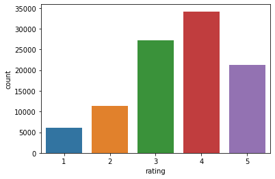

```python
sns.countplot(UserRating['rating'])

#plots count of ratings
```

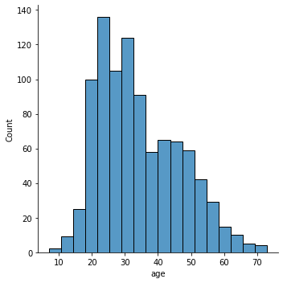

```python
sns.displot(User['age'])
```

```python
#your code here

#sns.countplot(Movies['release date'])

Movies['Year'] = pd.DatetimeIndex(Movies['release date']).year

Movies
```

|  | movie id | movie title | release date | unknown | Action | Adventure | Animation | Childrens | Comedy | Crime | ... | Horror | Musical | Mystery | Romance | Sci-Fi | Thriller | War | Western | total genre | Year |
| --- | --- | --- | --- | --- | --- | --- | --- | --- | --- | --- | --- | --- | --- | --- | --- | --- | --- | --- | --- | --- | --- |
| 0 | 1 | Toy Story | 01-Jan-1995 | 0 | 0 | 0 | 1 | 1 | 1 | 0 | ... | 0 | 0 | 0 | 0 | 0 | 0 | 0 | 0 | 3 | 1995 |
| 1 | 2 | GoldenEye | 01-Jan-1995 | 0 | 1 | 1 | 0 | 0 | 0 | 0 | ... | 0 | 0 | 0 | 0 | 0 | 1 | 0 | 0 | 3 | 1995 |
| 2 | 3 | Four Rooms | 01-Jan-1995 | 0 | 0 | 0 | 0 | 0 | 0 | 0 | ... | 0 | 0 | 0 | 0 | 0 | 1 | 0 | 0 | 1 | 1995 |
| 3 | 4 | Get Shorty | 01-Jan-1995 | 0 | 1 | 0 | 0 | 0 | 1 | 0 | ... | 0 | 0 | 0 | 0 | 0 | 0 | 0 | 0 | 3 | 1995 |
| 4 | 5 | Copycat | 01-Jan-1995 | 0 | 0 | 0 | 0 | 0 | 0 | 1 | ... | 0 | 0 | 0 | 0 | 0 | 1 | 0 | 0 | 3 | 1995 |
| ... | ... | ... | ... | ... | ... | ... | ... | ... | ... | ... | ... | ... | ... | ... | ... | ... | ... | ... | ... | ... | ... |
| 1676 | 1678 | Mat' i syn | 06-Feb-1998 | 0 | 0 | 0 | 0 | 0 | 0 | 0 | ... | 0 | 0 | 0 | 0 | 0 | 0 | 0 | 0 | 1 | 1998 |
| 1677 | 1679 | B. Monkey | 06-Feb-1998 | 0 | 0 | 0 | 0 | 0 | 0 | 0 | ... | 0 | 0 | 0 | 1 | 0 | 1 | 0 | 0 | 2 | 1998 |
| 1678 | 1680 | Sliding Doors | 01-Jan-1998 | 0 | 0 | 0 | 0 | 0 | 0 | 0 | ... | 0 | 0 | 0 | 1 | 0 | 0 | 0 | 0 | 2 | 1998 |
| 1679 | 1681 | You So Crazy | 01-Jan-1994 | 0 | 0 | 0 | 0 | 0 | 1 | 0 | ... | 0 | 0 | 0 | 0 | 0 | 0 | 0 | 0 | 1 | 1994 |
| 1680 | 1682 | Scream of Stone (Schrei aus Stein) | 08-Mar-1996 | 0 | 0 | 0 | 0 | 0 | 0 | 0 | ... | 0 | 0 | 0 | 0 | 0 | 0 | 0 | 0 | 1 | 1996 |

1680 rows × 24 columns

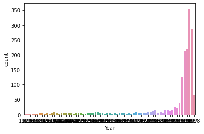

```python
#sns.countplot(Movies['Year'])

sns.countplot(x ='Year', data = Movies)
```

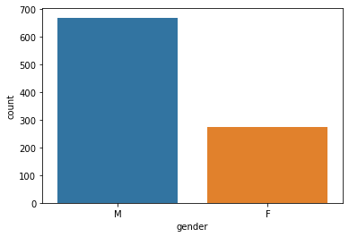

```python
sns.countplot(x ='gender', data = User)

#plots count of 'gender'
```

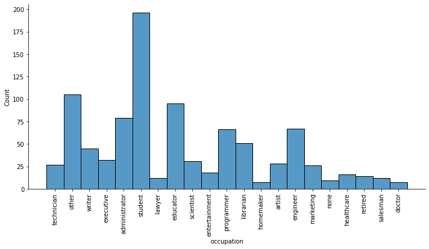

```python
occ= sns.displot(x ='occupation', data = User, aspect=2)

occ.set_xticklabels(rotation=90)
```

### 8. Visualize how popularity of genres has changed over the years - 10 marks

Note that you need to use the **percent of number of releases in a year** as a parameter of popularity of a genre

Hint 1: You need to reach to a data frame where the release year is the index and the genre is the column names (one cell shows the number of release in a year in one genre) or vice versa. (Drop unnecessary column if there are any)

Hint 2: Find the total number of movies release in a year(use item dataset to get count of movies released in a particular year, store that value in a new column as 'total'). Now divide the value of each genre in that year by total to get percentage number of release in a particular year. `(df.div(df['total'], axis= 0) * 100)`

Once that is achieved, you can either use univariate plots or can use the heatmap to visualise all the changes over the years in one go.

Hint 3: Use groupby on the relevant column and use sum() on the same to find out the number of releases in a year/genre.

```python
YearSum = Movies.groupby(by='Year').sum()
```

```python
YearSum.pop("movie id")

YearSum.pop("unknown")

#removes 'movie id' & 'unkown'
```

```
Year
1922    0
1926    0
1930    0
1931    0
1932    0
       ..
1994    0
1995    0
1996    0
1997    0
1998    0
Name: unknown, Length: 71, dtype: int64
```

```python
YearSum
```

| Year | Action | Adventure | Animation | Childrens | Comedy | Crime | Documentary | Drama | Fantasy | Film-Noir | Horror | Musical | Mystery | Romance | Sci-Fi | Thriller | War | Western | total genre |
| --- | --- | --- | --- | --- | --- | --- | --- | --- | --- | --- | --- | --- | --- | --- | --- | --- | --- | --- | --- |
| 1922 | 0 | 0 | 0 | 0 | 0 | 0 | 0 | 0 | 0 | 0 | 1 | 0 | 0 | 0 | 0 | 0 | 0 | 0 | 1 |
| 1926 | 0 | 0 | 0 | 0 | 0 | 0 | 0 | 1 | 0 | 0 | 0 | 0 | 0 | 0 | 0 | 0 | 0 | 0 | 1 |
| 1930 | 0 | 0 | 0 | 0 | 0 | 0 | 0 | 1 | 0 | 0 | 0 | 0 | 0 | 0 | 0 | 0 | 0 | 0 | 1 |
| 1931 | 0 | 0 | 0 | 0 | 0 | 1 | 0 | 0 | 0 | 1 | 0 | 0 | 0 | 0 | 0 | 1 | 0 | 0 | 3 |
| 1932 | 0 | 0 | 0 | 0 | 0 | 0 | 0 | 0 | 0 | 0 | 0 | 0 | 0 | 1 | 0 | 0 | 1 | 0 | 2 |
| ... | ... | ... | ... | ... | ... | ... | ... | ... | ... | ... | ... | ... | ... | ... | ... | ... | ... | ... | ... |
| 1994 | 30 | 13 | 4 | 15 | 82 | 8 | 9 | 97 | 3 | 0 | 8 | 2 | 2 | 35 | 7 | 25 | 7 | 6 | 353 |
| 1995 | 40 | 22 | 6 | 21 | 63 | 11 | 5 | 89 | 3 | 1 | 14 | 3 | 5 | 37 | 15 | 39 | 5 | 2 | 381 |
| 1996 | 44 | 24 | 9 | 21 | 108 | 21 | 18 | 170 | 6 | 1 | 11 | 9 | 6 | 38 | 15 | 47 | 9 | 2 | 559 |
| 1997 | 46 | 20 | 3 | 22 | 87 | 30 | 6 | 113 | 4 | 2 | 8 | 5 | 18 | 51 | 13 | 54 | 14 | 0 | 496 |
| 1998 | 12 | 3 | 0 | 1 | 13 | 7 | 3 | 33 | 1 | 2 | 4 | 1 | 3 | 11 | 5 | 18 | 0 | 0 | 117 |

71 rows × 19 columns

```python
#this will calculate the percentage of each movie category in each year

PercentMovie = YearSum.div(YearSum['total genre'], axis= 0) * 100

PercentMovie
```

| Year | Action | Adventure | Animation | Childrens | Comedy | Crime | Documentary | Drama | Fantasy | Film-Noir | Horror | Musical | Mystery | Romance | Sci-Fi | Thriller | War | Western | total genre |
| --- | --- | --- | --- | --- | --- | --- | --- | --- | --- | --- | --- | --- | --- | --- | --- | --- | --- | --- | --- |
| 1922 | 0.000000 | 0.000000 | 0.000000 | 0.000000 | 0.000000 | 0.000000 | 0.000000 | 0.000000 | 0.000000 | 0.000000 | 100.000000 | 0.000000 | 0.000000 | 0.000000 | 0.000000 | 0.000000 | 0.000000 | 0.000000 | 100.0 |
| 1926 | 0.000000 | 0.000000 | 0.000000 | 0.000000 | 0.000000 | 0.000000 | 0.000000 | 100.000000 | 0.000000 | 0.000000 | 0.000000 | 0.000000 | 0.000000 | 0.000000 | 0.000000 | 0.000000 | 0.000000 | 0.000000 | 100.0 |
| 1930 | 0.000000 | 0.000000 | 0.000000 | 0.000000 | 0.000000 | 0.000000 | 0.000000 | 100.000000 | 0.000000 | 0.000000 | 0.000000 | 0.000000 | 0.000000 | 0.000000 | 0.000000 | 0.000000 | 0.000000 | 0.000000 | 100.0 |
| 1931 | 0.000000 | 0.000000 | 0.000000 | 0.000000 | 0.000000 | 33.333333 | 0.000000 | 0.000000 | 0.000000 | 33.333333 | 0.000000 | 0.000000 | 0.000000 | 0.000000 | 0.000000 | 33.333333 | 0.000000 | 0.000000 | 100.0 |
| 1932 | 0.000000 | 0.000000 | 0.000000 | 0.000000 | 0.000000 | 0.000000 | 0.000000 | 0.000000 | 0.000000 | 0.000000 | 0.000000 | 0.000000 | 0.000000 | 50.000000 | 0.000000 | 0.000000 | 50.000000 | 0.000000 | 100.0 |
| ... | ... | ... | ... | ... | ... | ... | ... | ... | ... | ... | ... | ... | ... | ... | ... | ... | ... | ... | ... |
| 1994 | 8.498584 | 3.682720 | 1.133144 | 4.249292 | 23.229462 | 2.266289 | 2.549575 | 27.478754 | 0.849858 | 0.000000 | 2.266289 | 0.566572 | 0.566572 | 9.915014 | 1.983003 | 7.082153 | 1.983003 | 1.699717 | 100.0 |
| 1995 | 10.498688 | 5.774278 | 1.574803 | 5.511811 | 16.535433 | 2.887139 | 1.312336 | 23.359580 | 0.787402 | 0.262467 | 3.674541 | 0.787402 | 1.312336 | 9.711286 | 3.937008 | 10.236220 | 1.312336 | 0.524934 | 100.0 |
| 1996 | 7.871199 | 4.293381 | 1.610018 | 3.756708 | 19.320215 | 3.756708 | 3.220036 | 30.411449 | 1.073345 | 0.178891 | 1.967800 | 1.610018 | 1.073345 | 6.797853 | 2.683363 | 8.407871 | 1.610018 | 0.357782 | 100.0 |
| 1997 | 9.274194 | 4.032258 | 0.604839 | 4.435484 | 17.540323 | 6.048387 | 1.209677 | 22.782258 | 0.806452 | 0.403226 | 1.612903 | 1.008065 | 3.629032 | 10.282258 | 2.620968 | 10.887097 | 2.822581 | 0.000000 | 100.0 |
| 1998 | 10.256410 | 2.564103 | 0.000000 | 0.854701 | 11.111111 | 5.982906 | 2.564103 | 28.205128 | 0.854701 | 1.709402 | 3.418803 | 0.854701 | 2.564103 | 9.401709 | 4.273504 | 15.384615 | 0.000000 | 0.000000 | 100.0 |

71 rows × 19 columns

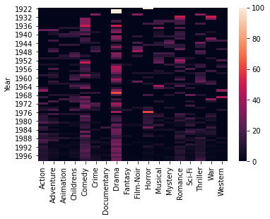

```python
PercentMovie.pop("total genre")

Heat = sns.heatmap(PercentMovie,fmt="d")

#if we were to remove some early dates the heat map would be easier to read since some year only had 1 genre
```

**Insights:**

Some early years (1922, 1926, 1930) only had one genre of movie. That means that people did not have enough choices to choose from and we would not be able to make a good analysis on the preferred genres tastes of people. It would be better to start analizing later years where more choices were available to see the change in genre preferences.

"Life is a comedy to those who think, and a tragedy to those who feel." - Hugh Walpole. <- I think this guy was right.

### 9. Find the top 25 movies in terms of average ratings for movies that have been rated more than 100 times - 10 marks

Hints :

1. Find the count of ratings and average ratings for every movie.
2. Slice the movies which have ratings more than 100.
3. Sort values according to average rating such that movie which highest rating is on top.
4. Select top 25 movies.
5. You will have to use the .merge() function to get the movie titles.

Note: This question will need you to research about groupby and apply your findings. You can find more on groupby on https://realpython.com/pandas-groupby/.

```python
#groups by movie id and calculates the mean

u = UserRating.groupby(by='movie id').mean()

u
```

| movie id | user id | rating | timestamp |
| --- | --- | --- | --- |
| 1 | 477.011062 | 3.878319 | 8.828054e+08 |
| 2 | 492.007634 | 3.206107 | 8.834174e+08 |
| 3 | 459.133333 | 3.033333 | 8.822269e+08 |
| 4 | 469.497608 | 3.550239 | 8.827175e+08 |
| 5 | 439.372093 | 3.302326 | 8.825882e+08 |
| ... | ... | ... | ... |
| 1678 | 863.000000 | 1.000000 | 8.892896e+08 |
| 1679 | 863.000000 | 3.000000 | 8.892895e+08 |
| 1680 | 863.000000 | 2.000000 | 8.892896e+08 |
| 1681 | 896.000000 | 3.000000 | 8.871607e+08 |
| 1682 | 916.000000 | 3.000000 | 8.808458e+08 |

1682 rows × 3 columns

```python
UserRating.groupby(by='movie id').describe()

# thia shows relevant data such as count and mean
```

| movie id | user id count | user id mean | user id std | user id min | user id 25% | user id 50% | user id 75% | user id max | rating count | rating mean | rating ... | rating 75% | rating max | timestamp count | timestamp mean | timestamp std | timestamp min | timestamp 25% | timestamp 50% | timestamp 75% | timestamp max |
| --- | --- | --- | --- | --- | --- | --- | --- | --- | --- | --- | --- | --- | --- | --- | --- | --- | --- | --- | --- | --- | --- |
| 1 | 452.0 | 477.011062 | 273.652445 | 1.0 | 250.75 | 471.5 | 711.00 | 941.0 | 452.0 | 3.878319 | ... | 5.0 | 5.0 | 452.0 | 8.828054e+08 | 5.255201e+06 | 874784615.0 | 8.792123e+08 | 881449772.5 | 8.867516e+08 | 893264174.0 |
| 2 | 131.0 | 492.007634 | 267.061546 | 1.0 | 277.50 | 484.0 | 732.50 | 943.0 | 131.0 | 3.206107 | ... | 4.0 | 5.0 | 131.0 | 8.834174e+08 | 5.340671e+06 | 874778568.0 | 8.793782e+08 | 882827375.0 | 8.884592e+08 | 893119336.0 |
| 3 | 90.0 | 459.133333 | 257.294882 | 1.0 | 268.25 | 457.5 | 623.50 | 936.0 | 90.0 | 3.033333 | ... | 4.0 | 5.0 | 90.0 | 8.822269e+08 | 5.012258e+06 | 874786924.0 | 8.788174e+08 | 881396339.5 | 8.858017e+08 | 892790676.0 |
| 4 | 209.0 | 469.497608 | 258.161624 | 1.0 | 280.00 | 455.0 | 664.00 | 940.0 | 209.0 | 3.550239 | ... | 4.0 | 5.0 | 209.0 | 8.827175e+08 | 5.501285e+06 | 874730179.0 | 8.787383e+08 | 881177459.0 | 8.878192e+08 | 893265741.0 |
| 5 | 86.0 | 439.372093 | 258.042270 | 1.0 | 269.25 | 390.5 | 646.75 | 925.0 | 86.0 | 3.302326 | ... | 4.0 | 5.0 | 86.0 | 8.825882e+08 | 5.372766e+06 | 874792692.0 | 8.788725e+08 | 881159461.0 | 8.866194e+08 | 893194607.0 |
| ... | ... | ... | ... | ... | ... | ... | ... | ... | ... | ... | ... | ... | ... | ... | ... | ... | ... | ... | ... | ... | ... |
| 1678 | 1.0 | 863.000000 | NaN | 863.0 | 863.00 | 863.0 | 863.00 | 863.0 | 1.0 | 1.000000 | ... | 1.0 | 1.0 | 1.0 | 8.892896e+08 | NaN | 889289570.0 | 8.892896e+08 | 889289570.0 | 8.892896e+08 | 889289570.0 |
| 1679 | 1.0 | 863.000000 | NaN | 863.0 | 863.00 | 863.0 | 863.00 | 863.0 | 1.0 | 3.000000 | ... | 3.0 | 3.0 | 1.0 | 8.892895e+08 | NaN | 889289491.0 | 8.892895e+08 | 889289491.0 | 8.892895e+08 | 889289491.0 |
| 1680 | 1.0 | 863.000000 | NaN | 863.0 | 863.00 | 863.0 | 863.00 | 863.0 | 1.0 | 2.000000 | ... | 2.0 | 2.0 | 1.0 | 8.892896e+08 | NaN | 889289570.0 | 8.892896e+08 | 889289570.0 | 8.892896e+08 | 889289570.0 |
| 1681 | 1.0 | 896.000000 | NaN | 896.0 | 896.00 | 896.0 | 896.00 | 896.0 | 1.0 | 3.000000 | ... | 3.0 | 3.0 | 1.0 | 8.871607e+08 | NaN | 887160722.0 | 8.871607e+08 | 887160722.0 | 8.871607e+08 | 887160722.0 |
| 1682 | 1.0 | 916.000000 | NaN | 916.0 | 916.00 | 916.0 | 916.00 | 916.0 | 1.0 | 3.000000 | ... | 3.0 | 3.0 | 1.0 | 8.808458e+08 | NaN | 880845755.0 | 8.808458e+08 | 880845755.0 | 8.808458e+08 | 880845755.0 |

1682 rows × 24 columns

```python
#could not get .describe() to work for the following sections, so had to create new  lists and merged them
```

```python
u = u.rename(columns={'rating': 'avg rating'})
```

[output not shown]

1682 rows × 3 columns

```python
c = UserRating.groupby(by='movie id').count()
```

[output not shown]

1682 rows × 3 columns

```python
merged = pd.merge(u, c, how='inner', on='movie id')

# used this method since I could not get .describe() to work for this
```

```python
merged.pop("user id_x")

merged.pop("timestamp_x")

merged.pop("user id_y")

merged.pop("timestamp_y")

merged = merged.loc[merged['rating'] > 100]
merged


#this prints movies with ratings greater than 100
#removed unnecessary columns with .pop()
```

| movie id | avg rating | rating |
| --- | --- | --- |
| 1 | 3.878319 | 452 |
| 2 | 3.206107 | 131 |
| 4 | 3.550239 | 209 |
| 7 | 3.798469 | 392 |
| 8 | 3.995434 | 219 |
| ... | ... | ... |
| 926 | 2.702970 | 101 |
| 928 | 3.115385 | 104 |
| 1016 | 3.459854 | 137 |
| 1028 | 3.040541 | 148 |
| 1047 | 2.835821 | 134 |

334 rows × 2 columns

```python
sort = merged.sort_values(['avg rating'], ascending=[0])


sort

#sorts by descending values by avg rating
```

| movie id | avg rating | rating |
| --- | --- | --- |
| 408 | 4.491071 | 112 |
| 318 | 4.466443 | 298 |
| 169 | 4.466102 | 118 |
| 483 | 4.456790 | 243 |
| 64 | 4.445230 | 283 |
| ... | ... | ... |
| 358 | 2.615385 | 143 |
| 260 | 2.574803 | 127 |
| 325 | 2.546875 | 128 |
| 243 | 2.439394 | 132 |
| 122 | 2.339623 | 106 |

334 rows × 2 columns

```python
#top 25 movies by avg rating

#prints top 25

Cinema25 = sort.head(25)

#merged data so movie title & release release date are now included

Cinema25 = pd.merge(Cinema25, Movies, how = 'left', on = 'movie id')

Cinema25[['movie id','avg rating','movie title','release date']]
```

|  | movie id | avg rating | movie title | release date |
| --- | --- | --- | --- | --- |
| 0 | 408 | 4.491071 | Close Shave, A | 28-Apr-1996 |
| 1 | 318 | 4.466443 | Schindler's List | 01-Jan-1993 |
| 2 | 169 | 4.466102 | Wrong Trousers, The | 01-Jan-1993 |
| 3 | 483 | 4.456790 | Casablanca | 01-Jan-1942 |
| 4 | 64 | 4.445230 | Shawshank Redemption, The | 01-Jan-1994 |
| 5 | 603 | 4.387560 | Rear Window | 01-Jan-1954 |
| 6 | 12 | 4.385768 | Usual Suspects, The | 14-Aug-1995 |
| 7 | 50 | 4.358491 | Star Wars | 01-Jan-1977 |
| 8 | 178 | 4.344000 | 12 Angry Men | 01-Jan-1957 |
| 9 | 134 | 4.292929 | Citizen Kane | 01-Jan-1941 |
| 10 | 427 | 4.292237 | To Kill a Mockingbird | 01-Jan-1962 |
| 11 | 357 | 4.291667 | One Flew Over the Cuckoo's Nest | 01-Jan-1975 |
| 12 | 98 | 4.289744 | Silence of the Lambs, The | 01-Jan-1991 |
| 13 | 480 | 4.284916 | North by Northwest | 01-Jan-1959 |
| 14 | 127 | 4.283293 | Godfather, The | 01-Jan-1972 |
| 15 | 285 | 4.265432 | Secrets & Lies | 04-Oct-1996 |
| 16 | 272 | 4.262626 | Good Will Hunting | 01-Jan-1997 |
| 17 | 657 | 4.259542 | Manchurian Candidate, The | 01-Jan-1962 |
| 18 | 474 | 4.252577 | Dr. Strangelove or: How I Learned to Stop Worr... | 01-Jan-1963 |
| 19 | 174 | 4.252381 | Raiders of the Lost Ark | 01-Jan-1981 |
| 20 | 479 | 4.251397 | Vertigo | 01-Jan-1958 |
| 21 | 313 | 4.245714 | Titanic | 01-Jan-1997 |
| 22 | 511 | 4.231214 | Lawrence of Arabia | 01-Jan-1962 |
| 23 | 484 | 4.210145 | Maltese Falcon, The | 01-Jan-1941 |
| 24 | 172 | 4.204360 | Empire Strikes Back, The | 01-Jan-1980 |

### 10. Check for the validity of the below statements with respect to the data provided - 10 marks

- Men watch more drama than women
- Women watch more Sci-Fi than men
- Men watch more Romance than women

**compare the percentages**

**Please pay attention to what should be the denominator while calculating percentages**

1. Merge all the datasets
2. There is no need to conduct statistical tests around this. Just **compare the percentages** and comment on the validity of the above statements.
3. you might want ot use the .sum(), .div() function here.
4. Use number of ratings to validate the numbers. For example, if out of 4000 ratings received by women, 3000 are for drama, we will assume that 75% of the women watch drama.

```python
#your code here
```

```python
#merged User and UserRating using 'user id' and called it merged_total
#then merged merged_total and Movies using 'movie id'

merged_total = pd.merge(UserRating, User, how = 'left', on = 'user id')

merged_total = pd.merge(merged_total, Movies, how = 'left', on = 'movie id')


merged_total #this is all of the data merged
```

|  | user id | movie id | rating | timestamp | age | gender | occupation | zip code | movie title | release date | ... | Horror | Musical | Mystery | Romance | Sci-Fi | Thriller | War | Western | total genre | Year |
| --- | --- | --- | --- | --- | --- | --- | --- | --- | --- | --- | --- | --- | --- | --- | --- | --- | --- | --- | --- | --- | --- |
| 0 | 196 | 242 | 3 | 881250949 | 49 | M | writer | 55105 | Kolya | 24-Jan-1997 | ... | 0.0 | 0.0 | 0.0 | 0.0 | 0.0 | 0.0 | 0.0 | 0.0 | 1.0 | 1997.0 |
| 1 | 186 | 302 | 3 | 891717742 | 39 | F | executive | 00000 | L.A. Confidential | 01-Jan-1997 | ... | 0.0 | 0.0 | 1.0 | 0.0 | 0.0 | 1.0 | 0.0 | 0.0 | 4.0 | 1997.0 |
| 2 | 22 | 377 | 1 | 878887116 | 25 | M | writer | 40206 | Heavyweights | 01-Jan-1994 | ... | 0.0 | 0.0 | 0.0 | 0.0 | 0.0 | 0.0 | 0.0 | 0.0 | 2.0 | 1994.0 |
| 3 | 244 | 51 | 2 | 880606923 | 28 | M | technician | 80525 | Legends of the Fall | 01-Jan-1994 | ... | 0.0 | 0.0 | 0.0 | 1.0 | 0.0 | 0.0 | 1.0 | 1.0 | 4.0 | 1994.0 |
| 4 | 166 | 346 | 1 | 886397596 | 47 | M | educator | 55113 | Jackie Brown | 01-Jan-1997 | ... | 0.0 | 0.0 | 0.0 | 0.0 | 0.0 | 0.0 | 0.0 | 0.0 | 2.0 | 1997.0 |
| ... | ... | ... | ... | ... | ... | ... | ... | ... | ... | ... | ... | ... | ... | ... | ... | ... | ... | ... | ... | ... | ... |
| 99995 | 880 | 476 | 3 | 880175444 | 13 | M | student | 83702 | First Wives Club, The | 14-Sep-1996 | ... | 0.0 | 0.0 | 0.0 | 0.0 | 0.0 | 0.0 | 0.0 | 0.0 | 1.0 | 1996.0 |
| 99996 | 716 | 204 | 5 | 879795543 | 36 | F | administrator | 44265 | Back to the Future | 01-Jan-1985 | ... | 0.0 | 0.0 | 0.0 | 0.0 | 1.0 | 0.0 | 0.0 | 0.0 | 2.0 | 1985.0 |
| 99997 | 276 | 1090 | 1 | 874795795 | 21 | M | student | 95064 | Sliver | 01-Jan-1993 | ... | 0.0 | 0.0 | 0.0 | 0.0 | 0.0 | 1.0 | 0.0 | 0.0 | 1.0 | 1993.0 |
| 99998 | 13 | 225 | 2 | 882399156 | 47 | M | educator | 29206 | 101 Dalmatians | 27-Nov-1996 | ... | 0.0 | 0.0 | 0.0 | 0.0 | 0.0 | 0.0 | 0.0 | 0.0 | 2.0 | 1996.0 |
| 99999 | 12 | 203 | 3 | 879959583 | 28 | F | other | 06405 | Unforgiven | 01-Jan-1992 | ... | 0.0 | 0.0 | 0.0 | 0.0 | 0.0 | 0.0 | 0.0 | 1.0 | 1.0 | 1992.0 |

100000 rows × 31 columns

```python
merged_total.groupby('gender').size()

#total number of men and women who watched movies
```

```
gender
F    25740
M    74260
dtype: int64
```

```python
merged_total.groupby(['gender', 'Romance']).size()

#total number of men and women who watched Romance
# 1 indicates females/males that saw the genre, 0 indicates those that didnt
# adding ones and zeros gives us the total number of men and women
```

```
gender  Romance
F       0.0        19880
        1.0         5858
M       0.0        60649
        1.0        13603
dtype: int64
```

```python
merged_total.groupby(['gender', 'Drama']).size()

#total number of men and women who watched Drama
# 1 indicates females/males that saw the genre, 0 indicates those that didnt
# adding ones and zeros gives us the total number of men and women
```

```
gender  Drama
F       0.0      14730
        1.0      11008
M       0.0      45365
        1.0      28887
dtype: int64
```

```python
merged_total.groupby(['gender', 'Sci-Fi']).size()

#total number of men and women who watched Sci-Fi
# 1 indicates females/males that saw the genre, 0 indicates those that didnt
# adding ones and zeros gives us the total number of men and women
```

```
gender  Sci-Fi
F       0.0       23109
        1.0        2629
M       0.0       64151
        1.0       10101
dtype: int64
```

```python
merged_total.groupby(['gender', 'Romance']).size() #total number of men and women

F = 25740 #number of total female ratings

F_voted_romance = 5850

F_watched_romance = F_voted_romance/F *100

print('Percentage of women that watched romance:',int(F_watched_romance), "%" )

M = 74260 #number of total men ratings

M_voted_romance = 13603

M_watched_romance = M_voted_romance/M *100

print('Percentage of men that watched romance:',int(M_watched_romance), "%" )
```

```
Percentage of women that watched romance: 22 %
Percentage of men that watched romance: 18 %
```

```python
merged_total.groupby(['gender', 'Sci-Fi']).size() #total number of men and women


merged_total.groupby(['gender', 'Sci-Fi']).size() #total number of men and women

F = 25740 #number of total female ratings

F_voted_scifi = 2629

F_watched_scifi = F_voted_scifi/F *100

print('Percentage of women that watched SciFi:',int(F_watched_scifi), "%" )

M = 74260 #number of total female ratings

M_voted_scifi = 10101

M_watched_scifi = M_voted_scifi/M *100

print('Percentage of men that watched SciFi:',int(M_watched_scifi), "%" )
```

```
Percentage of women that watched SciFi: 10 %
Percentage of men that watched SciFi: 13 %
```

```python
merged_total.groupby(['gender', 'Drama']).size() #total number of men and women

F = 25740 #number of total female ratings

F_voted_drama = 11008

F_watched_drama = F_voted_drama/F *100

print('Percentage of women that watched drama:',int(F_watched_drama), "%" )

M = 74260 #number of total female ratings

M_voted_drama = 28887

M_watched_drama = M_voted_drama/M *100

print('Percentage of men that watched drama:',int(M_watched_drama), "%" )
```

```
Percentage of women that watched drama: 42 %
Percentage of men that watched drama: 38 %
```

**Conclusion:**

Men watch more drama than women = False; 42% of women vs 38% of men

Women watch more Sci-Fi than men = False; 10% of wemen vs 13% of men

Men watch more Romance than women = False; 22% of women vs 18% of men